# Data Lab 3

Anin Nair

09-15-2023

## 1. Setup

Loading all the libraries needed and importing the World Bank CSV file using the *read.csv* function and then loading the first few lines of data using the *head* function

```r
library (tidyverse)
```

```r
library(ggplot2)
data = read.csv("world_bank.csv")
head(data)
```

|  | countrycode | year | country.name | trade | gdp | civilwar | democ |
| --- | --- | --- | --- | --- | --- | --- | --- |
| 1 | 2 | 2001 | United States | 22.84296 | 37.13324 | 1 | 10 |
| 2 | 2 | 2002 | United States | 22.15427 | 38.02316 | 1 | 10 |
| 3 | 2 | 2003 | United States | 22.47710 | 39.49649 | 1 | 10 |
| 4 | 2 | 2004 | United States | 24.35241 | 41.71280 | 1 | 10 |
| 5 | 2 | 2005 | United States | 25.55599 | 44.11475 | 1 | 10 |
| 6 | 2 | 2006 | United States | 26.90015 | 46.29873 | 1 | 10 |

## 2. Subset the Dataset

Subsetting the data just for the year 2018 from the entire csv file using the *subset* function

```r
year218 <- subset(data, year == "2018")
year218
```

|  | countrycode | year | country.name | trade | gdp | civilwar | democ |
| --- | --- | --- | --- | --- | --- | --- | --- |
| 18 | 2 | 2018 | United States | 27.56442 | 62.8400202 | 0 | 8 |
| 38 | 20 | 2018 | Canada | 66.11327 | 50.0777962 | 0 | 10 |
| 58 | 31 | 2018 | Bahamas, The | 77.35040 | 36.3382477 | 0 | NA |
| 78 | 40 | 2018 | Cuba | 27.09477 | NA | 0 | 1 |
| 98 | 41 | 2018 | Haiti | 75.54938 | 1.8088760 | 0 | 6 |
| 118 | 42 | 2018 | Dominican Republic | 52.05597 | 18.1297086 | 0 | 8 |
| 138 | 51 | 2018 | Jamaica | 89.02638 | 9.9677680 | 0 | 9 |
| 158 | 52 | 2018 | Trinidad and Tobago | NA | 26.8928681 | 0 | 10 |
| 178 | 53 | 2018 | Barbados | 80.99290 | 16.0447278 | 0 | NA |
| 198 | 70 | 2018 | Mexico | 80.44832 | 20.3964777 | 0 | 8 |

[output cut: 180 more lines]

## 3. Relationship between Trade and GDP

Using the *ggplot* function to create a scatter plot to visualize the relationship between Trade and GDP in the year 2018 for all the countries. A linear trend line also has been added to make the visualization easy to read. At first it seems like the countries with higher GDP, trade more however, on closer inspection there are way too many outliers for there to be a linear relationship

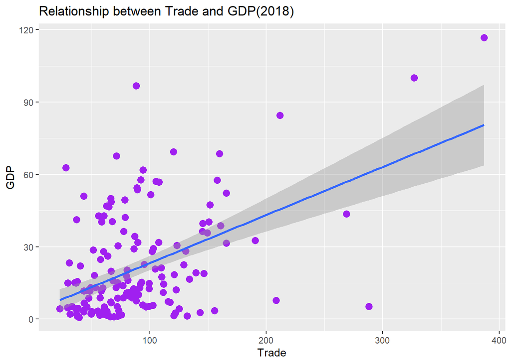

```r
plot1 <- ggplot(data = year218, mapping = aes(x = trade, y= gdp)) + labs(x= "Trade", y= "GDP") + geom_point(size = 3, color = "purple") + geom_smooth(method = lm) + ggtitle("Relationship between Trade and GDP(2018)")

plot1
```

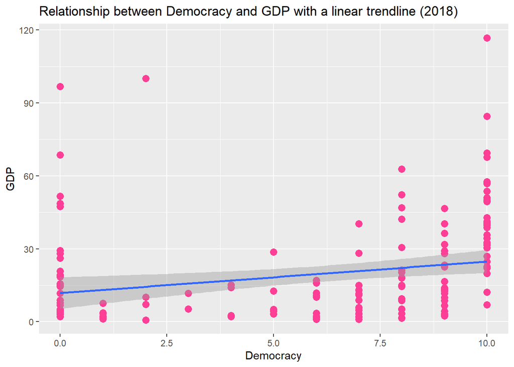

```r
plot2 <- ggplot(data = year218, mapping = aes(x = democ, y= gdp)) + labs(x= "Democracy", y= "GDP") + geom_point(size = 3, color = "violetred1") + geom_smooth(method = lm) + ggtitle("Relationship between Democracy and GDP with a linear trendline (2018)")

plot2
```

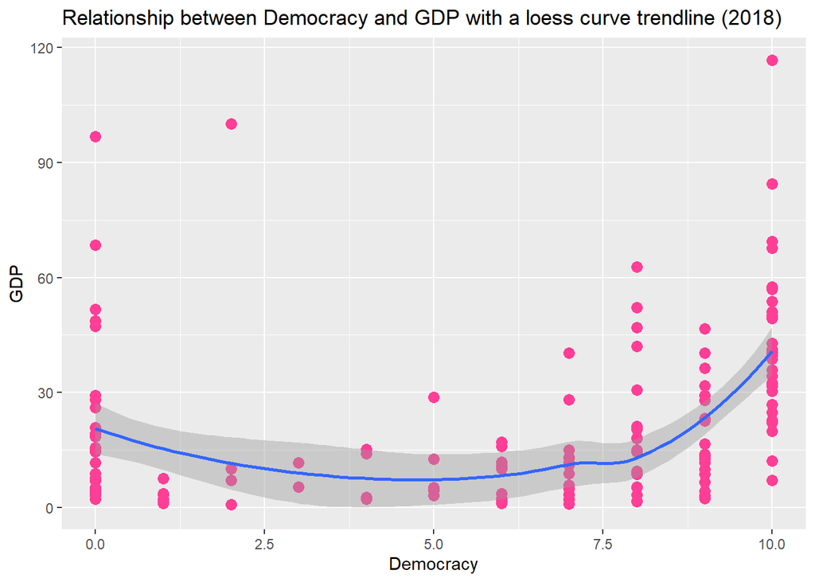

```r
plot3 <- ggplot(data = year218, mapping = aes(x = democ, y= gdp)) + labs(x= "Democracy", y= "GDP") + geom_point(size = 3, color = "violetred1") + geom_smooth() + ggtitle("Relationship between Democracy and GDP with a loess curve trendline (2018)")

plot3
```